# A549-HBE-ALI comparison analysis

Repo at https://github.com/axg610/a549-hbe-ali-comparison

We can edit in PowerPoint/apply a consistent theme to all the figures at the very end

# 1. ===== Alignment and DEA =====

**Raw datasets:** A549, primary hBECs (submersion culture, HBE), and primary hBECs (air-liquid interface culture, ALI) treated with IL1B, glucocorticoid, or both at 6h. This is actually three experiments at different timepoints, so for now we use their shared timepoint (6 h post-treatment).

Alignment performed with kallisto version 0.46.1 and normalization/DEA performed with sleuth version something on the cluster. Everything documented in `kallisto-sleuth.md`. I used individual sleuth runs for each cell type, modeled as `~treatment`. Effect sizes (“log2fold”) and FDR are from Wald test using unstimulated (NS) samples as baseline. I also modeled everything together under model `~treatment*condition` for interaction testing. Finally, raw tpm values were extracted.

Example univariate DEA data (~treatment)

| Gene | celltype | treatment | time | log2fold | FDR |
| --- | --- | --- | --- | --- | --- |
| NFKBIA | A549 | IL1B | 6h | 3.0341219 | 0.0000000 |
| NFKBIA | A549 | GC | 6h | 2.2055382 | 0.0000000 |
| NFKBIA | A549 | combo | 6h | 3.0864520 | 0.0000000 |
| NFKBIA | ALI | IL1B | 6h | 3.0640979 | 0.0000000 |
| NFKBIA | ALI | GC | 6h | 0.5737987 | 0.7668408 |
| NFKBIA | ALI | combo | 6h | 3.1271927 | 0.0000000 |
| NFKBIA | HBE | IL1B | 6h | 1.6700219 | 0.0000008 |
| NFKBIA | HBE | GC | 6h | 0.5918173 | 0.8067702 |
| NFKBIA | HBE | combo | 6h | 1.9126890 | 0.0000000 |

| Gene | lrt_FDR | ALI_IL1B_diff | ALI_IL1B_FDR | HBE_IL1B_diff | HBE_IL1B_FDR | ALI_GC_diff | ALI_GC_FDR | HBE_GC_diff | HBE_GC_FDR | ALI_combo_diff | ALI_combo_FDR | HBE_combo_diff | HBE_combo_FDR |
| --- | --- | --- | --- | --- | --- | --- | --- | --- | --- | --- | --- | --- | --- |
| IRAK3 | 0.00e+00 | -2.7730331 | 0.0000000 | -3.615402 | 0.0000000 | -5.024278 | 0.0000000 | -4.243510 | 0.0000000 | -5.0891347 | 0.0000000 | -5.199215 | 0.0000000 |
| NFKBIA | 2.50e-06 | -0.0081513 | 0.9953362 | -1.347587 | 0.0048081 | -1.624309 | 0.0010009 | -1.594663 | 0.0012972 | 0.0704543 | 0.9717566 | -1.146222 | 0.0357046 |
| TNFAIP3 | 5.07e-05 | -3.4185435 | 0.0000528 | -3.371705 | 0.0000718 | -1.738957 | 0.2649870 | -2.900867 | 0.0026622 | -2.7622790 | 0.0025900 | -3.342315 | 0.0001313 |

Example tpm data, first 20 rows for representative gene

| Gene | rep | celltype | treatment | time | tpm | log2tpm | fold | log2fold |
| --- | --- | --- | --- | --- | --- | --- | --- | --- |
| NFKBIA | R1 | A549 | NS | 6 | 40.04168 | 5.327029 | 1.000000 | 0.000000 |
| NFKBIA | R2 | A549 | NS | 6 | 41.81913 | 5.389537 | 1.000000 | 0.000000 |
| NFKBIA | R3 | A549 | NS | 6 | 41.59516 | 5.381808 | 1.000000 | 0.000000 |
| NFKBIA | R4 | A549 | NS | 6 | 34.95151 | 5.131405 | 1.000000 | 0.000000 |
| NFKBIA | R1 | A549 | IL1B | 6 | 310.19487 | 8.277496 | 7.729992 | 2.950467 |
| NFKBIA | R2 | A549 | IL1B | 6 | 303.63668 | 8.246677 | 7.245777 | 2.857140 |
| NFKBIA | R3 | A549 | IL1B | 6 | 338.65023 | 8.404078 | 8.124449 | 3.022270 |
| NFKBIA | R4 | A549 | IL1B | 6 | 293.10354 | 8.195759 | 8.364933 | 3.064354 |
| NFKBIA | R1 | A549 | GC | 6 | 182.44554 | 7.512113 | 4.547531 | 2.185084 |
| NFKBIA | R2 | A549 | GC | 6 | 184.85575 | 7.531036 | 4.412204 | 2.141499 |
| NFKBIA | R3 | A549 | GC | 6 | 196.77518 | 7.621137 | 4.721775 | 2.239329 |
| NFKBIA | R4 | A549 | GC | 6 | 156.80796 | 7.293775 | 4.476496 | 2.162370 |
| NFKBIA | R1 | A549 | combo | 6 | 324.53280 | 8.342665 | 8.087176 | 3.015636 |
| NFKBIA | R2 | A549 | combo | 6 | 331.03845 | 8.371291 | 7.899458 | 2.981754 |
| NFKBIA | R3 | A549 | combo | 6 | 331.14040 | 8.371735 | 7.944337 | 2.989927 |
| NFKBIA | R4 | A549 | combo | 6 | 304.50374 | 8.250790 | 8.690174 | 3.119385 |
| NFKBIA | donor57 | ALI | NS | 6 | 121.70039 | 6.928375 | 1.000000 | 0.000000 |
| NFKBIA | donor78 | ALI | NS | 6 | 56.69021 | 5.827570 | 1.000000 | 0.000000 |
| NFKBIA | donor82 | ALI | NS | 6 | 39.45922 | 5.305942 | 1.000000 | 0.000000 |
| NFKBIA | donor86 | ALI | NS | 6 | 35.42983 | 5.150959 | 1.000000 | 0.000000 |

# 2. ===== Story notes =====

Justify comparison at 6 h: majority of IL1B response observed at this timepoint, maybe most NFkappaB dependence as well? Maybe richest functional annotations? Other justifications?

## 2.1. IL1B responses seem to differ substantially between A549 and primary cells

**(A)** For genes deemed “regulated” by DEA (log2fold <= -1 or >= 1 & FDR < 0.05), only ~17% of the IL1B-regulated transcriptome is shared with at least one primary celltype. This figure increases to ~33% for IL1B-induced genes **(B)** and decreases to ~4% for IL1B-downregulated genes **(C)**. Overlaps remain robust when calling regulated genes with fold criteria only (~23% shared, **D**), or FDR only (~19% shared, **E**).

From a DEA perspective (all donors pooled together), IL1B-regulated transcriptomes in A549 and primary cells show low concordance. Start to see hints that the problem is worse for downregulated genes than it is for upregulated.

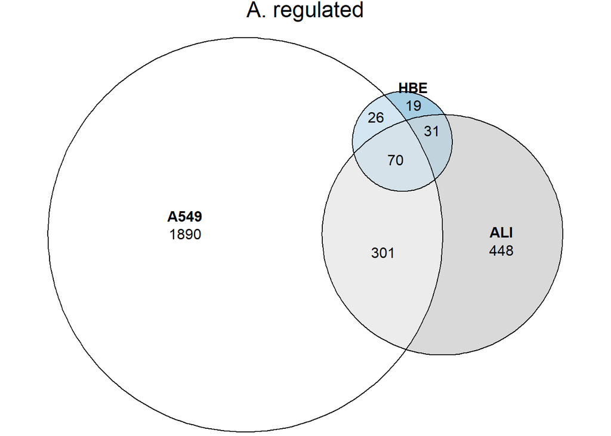

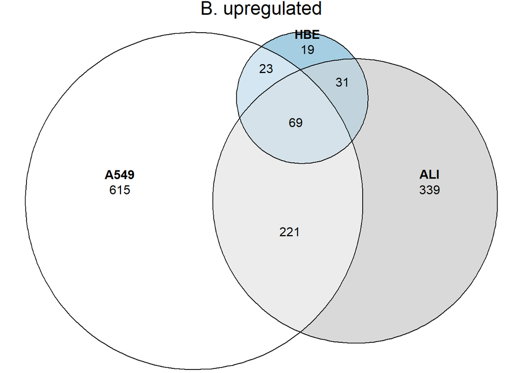

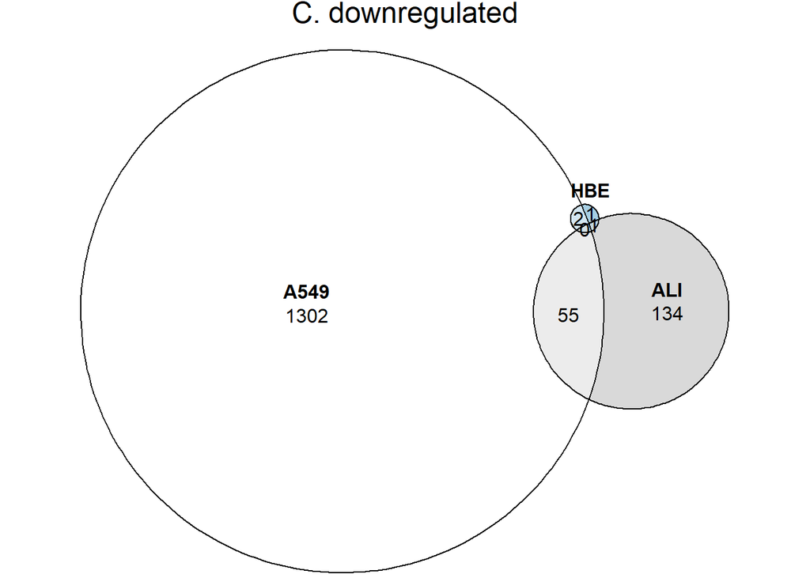

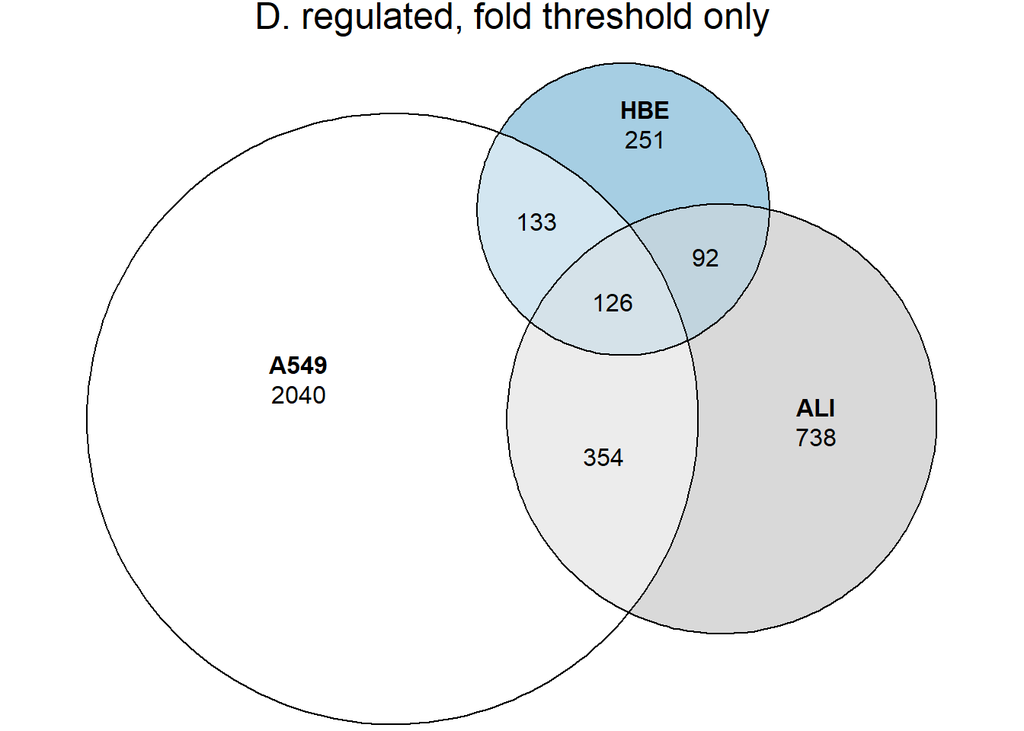

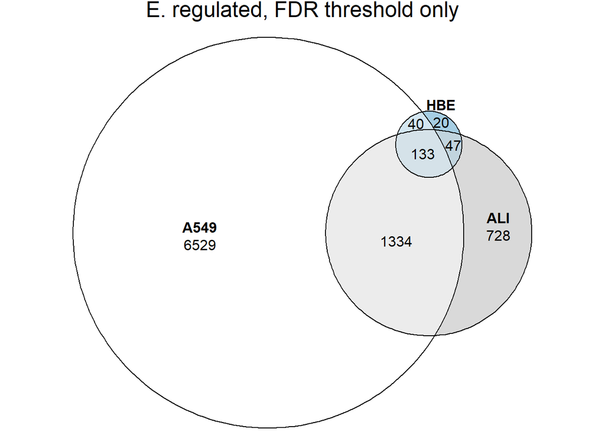

## 2.2. However, differences stem from between-donor variation

Low overlaps are likely a result of aggregating by celltype. A549 cells are derived from one individual, so each of the four replicates reflects one donor. Primary cells are derived from different individuals, where each replicate corresponds to a different donor. Thus, DEA easily identifies small/rare regulatory events in A549s, while penalizing donor-specific regulation in primary cells. **Instead of DEA, we can call a gene “regulated” if it meets the abs(log2fold) >= 1 threshold in a donor.**

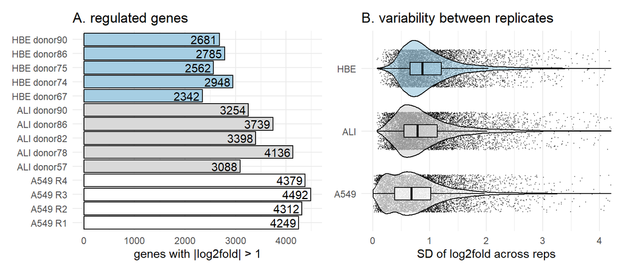

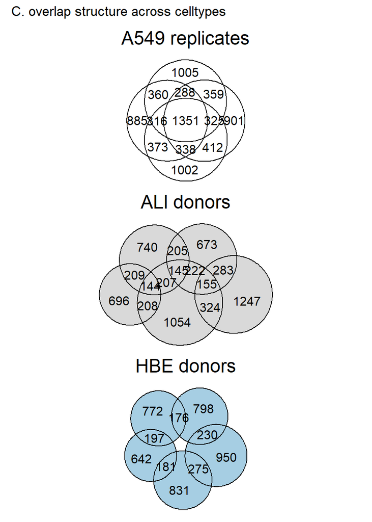

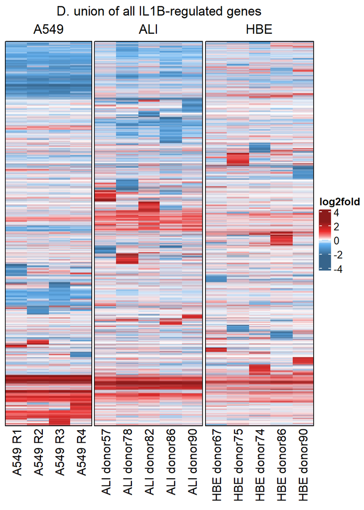

**(A) Individual variation dominates shared expression.** Compared to genes regulated in only one donor (left side, first 11 bars), there are much fewer genes shared between donors (right side) *(do a manual count?)*. Splitting the visualization into **(B)** upregulated and **(C)** downregulated genes reveals that A549s have “normal” IL1B-upregulated signatures (middle-of-the-pack in terms of unique upreg genes), but abberant IL1B-downregulated signatures (has the most downregulated genes). Additionally, the 54 completely conserved genes are exclusively upregulated. This suggests that the IL1B-induced response is more core/conserved while the downregulated response is more context/individual-specific.

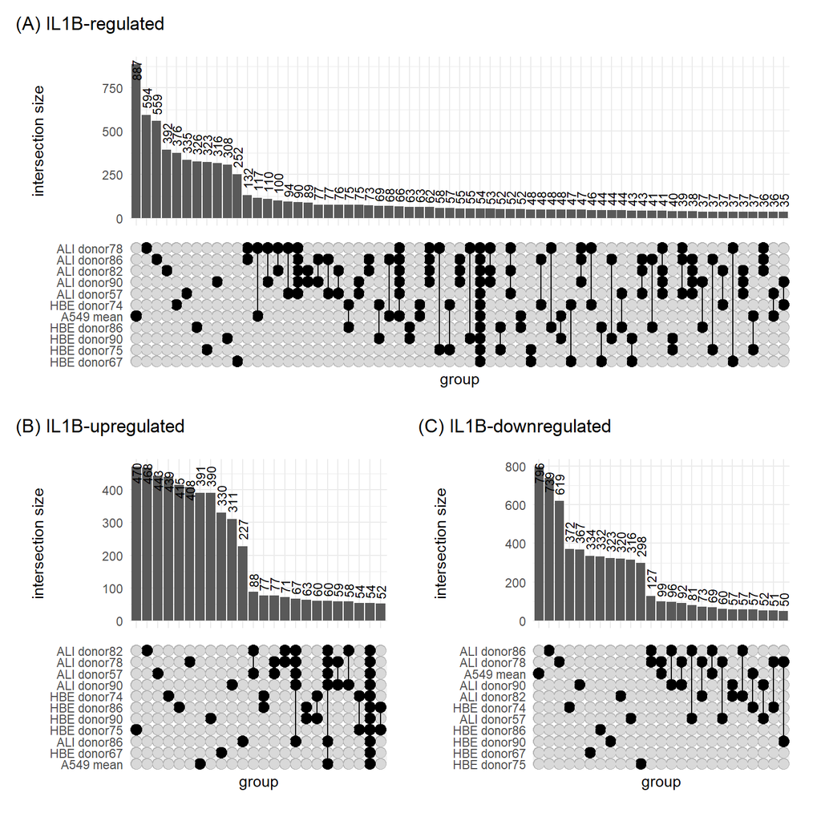

## 2.3. IN PROGRESS: A549s effectively capture what “could” happen across donors

Findings from 2.2. suggest that we should pivot from “intersection biology” to “union biology.” i.e., A549s do not recapitulate any single primary IL1B response, but capture a large fraction of the population-level transcriptional response (with a preference for induced programs). **To explore the extent to which A549-regulated gene expression overlaps with the union of all donor-regulated gene expression, fold values from the four A549 replicates were averaged into an “A549 mean” – representative of the A549 donor, to be compared against all other donors.**

**(A)** Showing all intersections with more than 10 genes, 887 genes were unique to A549 cells while 1040 were shared between A549 cells and at least one donor. Thus, **54% of the IL1B-regulated response in A549 cells represents something that could be observed within a population of donors.**

**(B)** Narrowing down into IL1B-induced genes, we see 391 unique to A549 cells anywhere between 286 (minimum intersection size = 10), and 514 shared (minimum intersection size 3). So more than 42-56% of the IL1B-induced signature in A549s is shared with at least one primary cell. **(C)** ~50% for downregulated genes.

[figure not shown]

[figure not shown]

[figure not shown]

To get an exact count, we plot as a Venn. This shows that 69% of the A549 response is recapitulated by at least 1 donor.

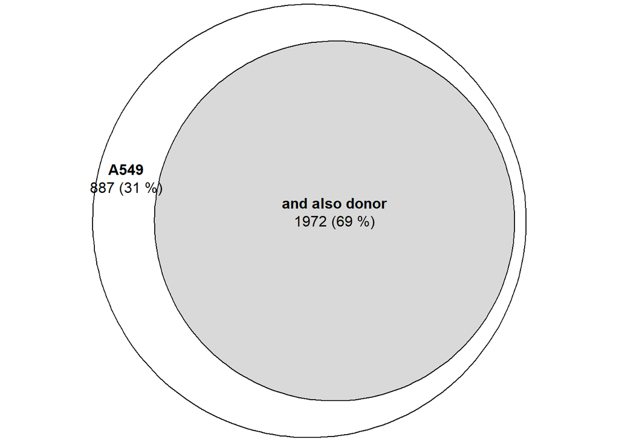

**However, A549s only capture 16% of the entire “donor universe”… So while the things that happen in A549s are most likely also found in 1+ donors, A549s themselves are not a perfect system for capturing everything that could happen?? Suggests considerable individual variation… But this variation should be in peripheral/context-dependent programs, while the core NFkappaB program should be faithfully captured by A549s (and map to primaries)**

Isn’t this the problem we had at the start ???

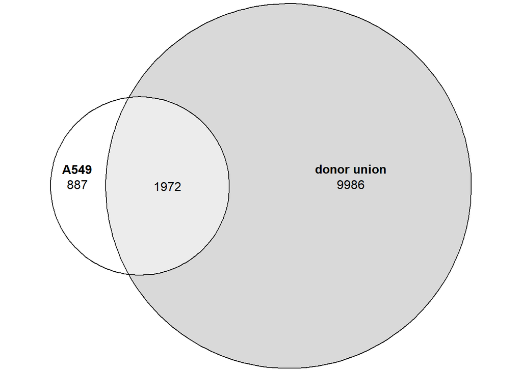

What if we take the A549 union instead of the A549 mean…

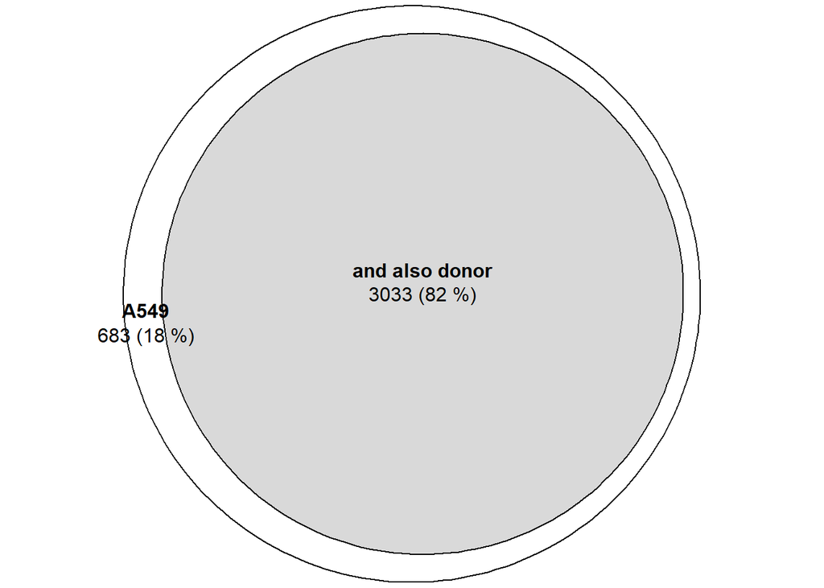

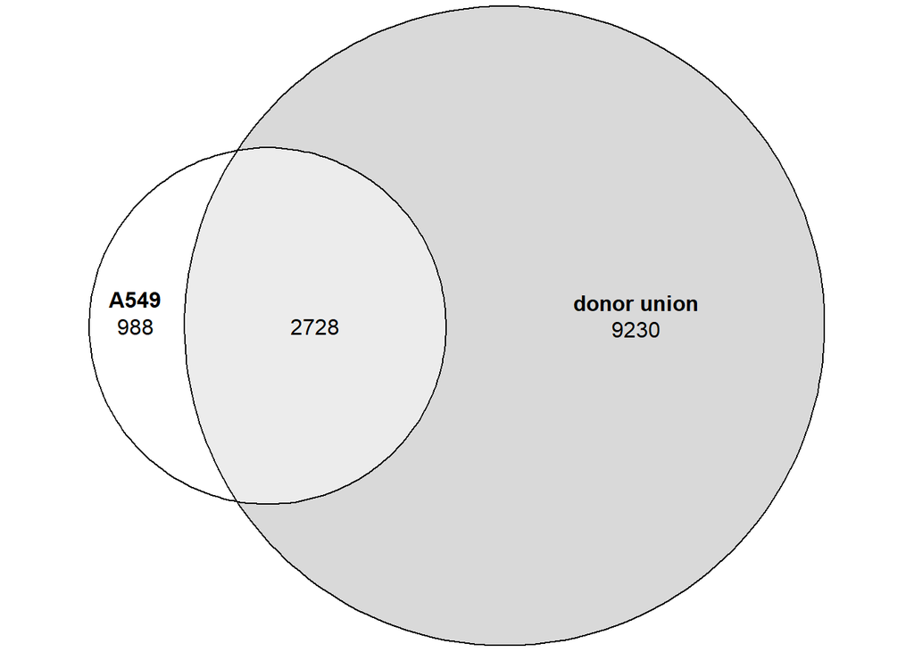

Same for each donor vs all other donors?